# Olympic_python_project

```python
import pandas as pd
import numpy as np
import seaborn as sns
import matplotlib.pyplot as plt

import warnings
warnings.filterwarnings("ignore")
```

```python
df = pd.read_csv(r"C:\Users\shiva\Downloads\Olympic.csv", encoding='latin1')
df.head(10)
```

|  | Athlete | Age | Country | Year | Date | Sport | Gold_Medals | Silver_Medals | Bronze_Medals | Total_Medals |
| --- | --- | --- | --- | --- | --- | --- | --- | --- | --- | --- |
| 0 | Michael Phelps | 23.0 | United States | 2008 | 8/24/2008 | Swimming | 8 | 0 | 0 | 8 |
| 1 | Michael Phelps | 19.0 | United States | 2004 | 8/29/2004 | Swimming | 6 | 0 | 2 | 8 |
| 2 | Michael Phelps | 27.0 | United States | 2012 | 8/12/2012 | Swimming | 4 | 2 | 0 | 6 |
| 3 | Natalie Coughlin | 25.0 | United States | 2008 | 8/24/2008 | Swimming | 1 | 2 | 3 | 6 |
| 4 | Aleksey Nemov | 24.0 | Russia | 2000 | 10/1/2000 | Gymnastics | 2 | 1 | 3 | 6 |
| 5 | Alicia Coutts | 24.0 | Australia | 2012 | 8/12/2012 | Swimming | 1 | 3 | 1 | 5 |
| 6 | Missy Franklin | 17.0 | United States | 2012 | 8/12/2012 | Swimming | 4 | 0 | 1 | 5 |
| 7 | Ryan Lochte | 27.0 | United States | 2012 | 8/12/2012 | Swimming | 2 | 2 | 1 | 5 |
| 8 | Allison Schmitt | 22.0 | United States | 2012 | 8/12/2012 | Swimming | 3 | 1 | 1 | 5 |
| 9 | Natalie Coughlin | 21.0 | United States | 2004 | 8/29/2004 | Swimming | 2 | 2 | 1 | 5 |

```python
df.duplicated().sum()
```

```
3
```

```python
df.drop_duplicates(inplace=True)
```

```python
df["Date"]=pd.to_datetime(df["Date"],errors="coerce")
```

```python
df.head(5)
```

|  | Athlete | Age | Country | Year | Date | Sport | Gold_Medals | Silver_Medals | Bronze_Medals | Total_Medals |
| --- | --- | --- | --- | --- | --- | --- | --- | --- | --- | --- |
| 0 | Michael Phelps | 23.0 | United States | 2008 | 2008-08-24 | Swimming | 8 | 0 | 0 | 8 |
| 1 | Michael Phelps | 19.0 | United States | 2004 | 2004-08-29 | Swimming | 6 | 0 | 2 | 8 |
| 2 | Michael Phelps | 27.0 | United States | 2012 | 2012-08-12 | Swimming | 4 | 2 | 0 | 6 |
| 3 | Natalie Coughlin | 25.0 | United States | 2008 | 2008-08-24 | Swimming | 1 | 2 | 3 | 6 |
| 4 | Aleksey Nemov | 24.0 | Russia | 2000 | 2000-10-01 | Gymnastics | 2 | 1 | 3 | 6 |

```python
df['Date'] = df['Date'].dt.strftime('%d-%m-%y')
```

```python
df.head(5)
```

|  | Athlete | Age | Country | Year | Date | Sport | Gold_Medals | Silver_Medals | Bronze_Medals | Total_Medals |
| --- | --- | --- | --- | --- | --- | --- | --- | --- | --- | --- |
| 0 | Michael Phelps | 23.0 | United States | 2008 | 24-08-08 | Swimming | 8 | 0 | 0 | 8 |
| 1 | Michael Phelps | 19.0 | United States | 2004 | 29-08-04 | Swimming | 6 | 0 | 2 | 8 |
| 2 | Michael Phelps | 27.0 | United States | 2012 | 12-08-12 | Swimming | 4 | 2 | 0 | 6 |
| 3 | Natalie Coughlin | 25.0 | United States | 2008 | 24-08-08 | Swimming | 1 | 2 | 3 | 6 |
| 4 | Aleksey Nemov | 24.0 | Russia | 2000 | 01-10-00 | Gymnastics | 2 | 1 | 3 | 6 |

### 1.Who is the most decorated athlete (won the most total medals)?

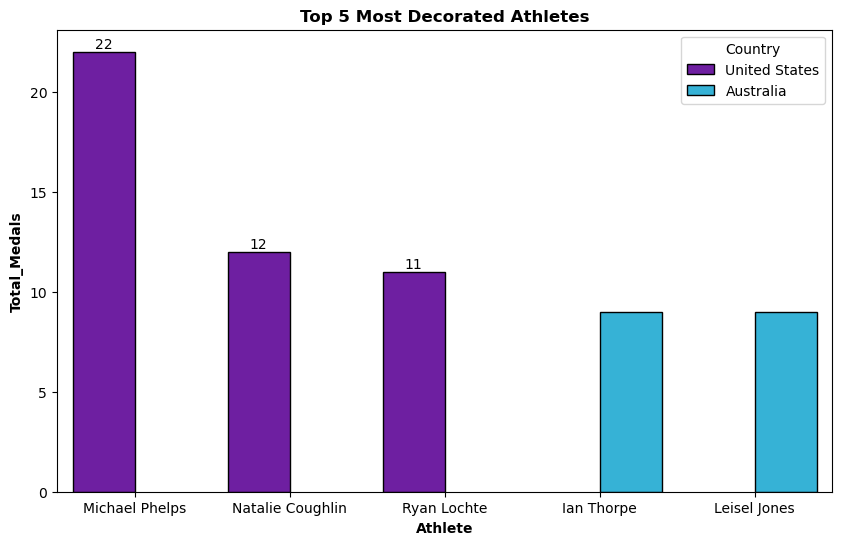

```python
dd=df.groupby(["Athlete","Country"])["Total_Medals"].sum().reset_index().sort_values(by="Total_Medals",ascending=False)
dd=dd.head(5)
plt.figure(figsize=(10,6))
ax=sns.barplot(x="Athlete",y="Total_Medals",hue="Country",data=dd,palette=["#7209B7", "#1CC0F0"],edgecolor="black")
ax.bar_label(ax.containers[0])
plt.title("Top 5 Most Decorated Athletes",fontweight="bold")
plt.xlabel("Athlete",fontweight="bold")
plt.ylabel("Total_Medals",fontweight="bold")
plt.show()
```

### 2.Which athlete has won the most gold medals?

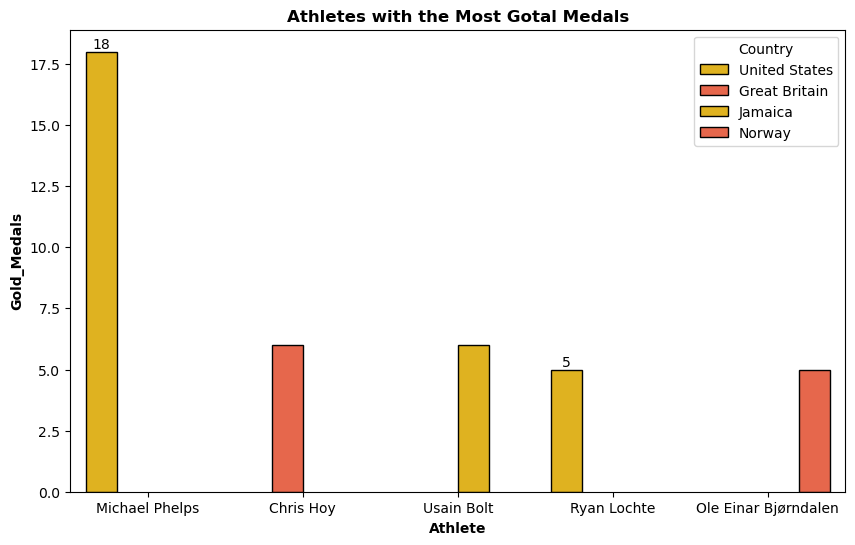

```python
dd=df.groupby(["Athlete","Country"])["Gold_Medals"].sum().reset_index().sort_values(by="Gold_Medals",ascending=False)
dd=dd.head(5)
plt.figure(figsize=(10,6))
ax=sns.barplot(x="Athlete",y="Gold_Medals",hue="Country",data=dd,palette=["#FFC300","#FF5733"],edgecolor="black")
ax.bar_label(ax.containers[0])
plt.title("Athletes with the Most Gotal Medals",fontweight="bold")
plt.xlabel("Athlete",fontweight="bold")
plt.ylabel("Gold_Medals",fontweight="bold")
plt.show()
```

### 3.Which country has won the most medals overall?

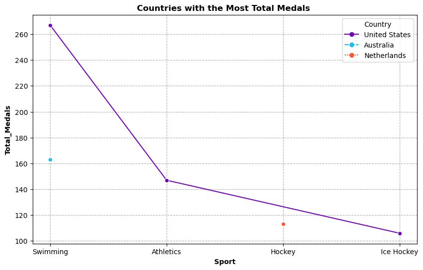

```python
dd=df.groupby(["Sport","Country"])["Total_Medals"].sum().reset_index().sort_values(by="Total_Medals",ascending=False)
dd=dd.head(5)
plt.figure(figsize=(10,6))
sns.lineplot(x="Sport",y="Total_Medals",hue="Country",data=dd,palette=["#7209B7", "#1CC0F0", "#FF5733"],markers=["o"],style="Country")
plt.title("Countries with the Most Total Medals ",fontweight="bold")
plt.xlabel("Sport",fontweight="bold")
plt.ylabel("Total_Medals",fontweight="bold")
plt.grid(linestyle="--")
plt.show()
```

### 4.Which sport has the most total medals across all years?

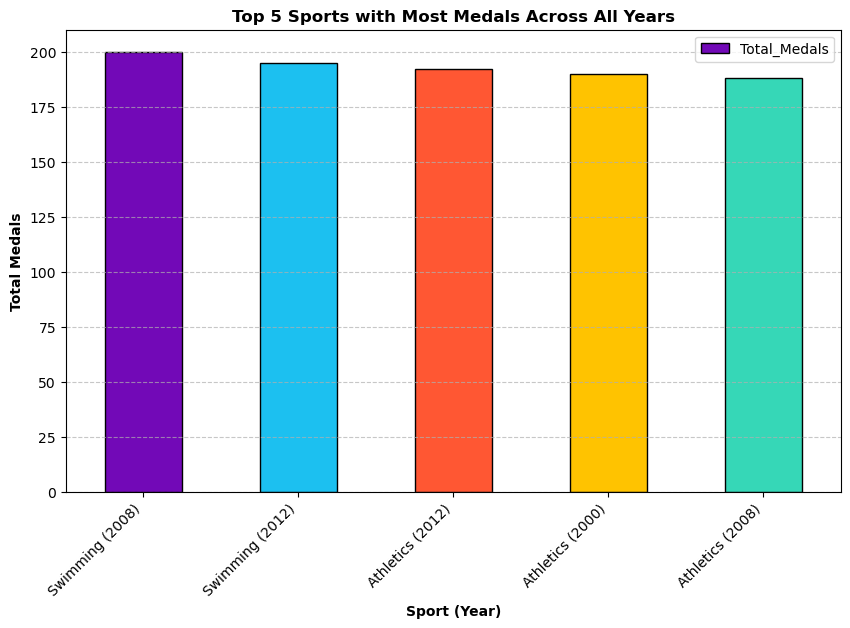

```python
dd = df.groupby(['Sport', 'Year'])["Total_Medals"].sum().reset_index().sort_values(by='Total_Medals', ascending=False)
dd = dd.head(5)
# Combine Sport and Year into one column for better labeling
dd["Sport_Year"] = dd["Sport"] + " (" + dd["Year"].astype(str) + ")"
fig, ax = plt.subplots(figsize=(10,6))
dd.plot(x="Sport_Year", y="Total_Medals", kind="bar", color=["#7209B7", "#1CC0F0", "#FF5733", "#FFC300", "#36D7B7"], edgecolor="black", ax=ax)
plt.title('Top 5 Sports with Most Medals Across All Years', fontweight="bold")
plt.xlabel('Sport (Year)', fontweight="bold")
plt.ylabel('Total Medals', fontweight="bold")
plt.xticks(rotation=45, ha="right")  # Rotate x-axis labels for better readability
plt.grid(axis="y", linestyle="--", alpha=0.7)
plt.show()
```

### 5.How has the number of total medals changed over the years?

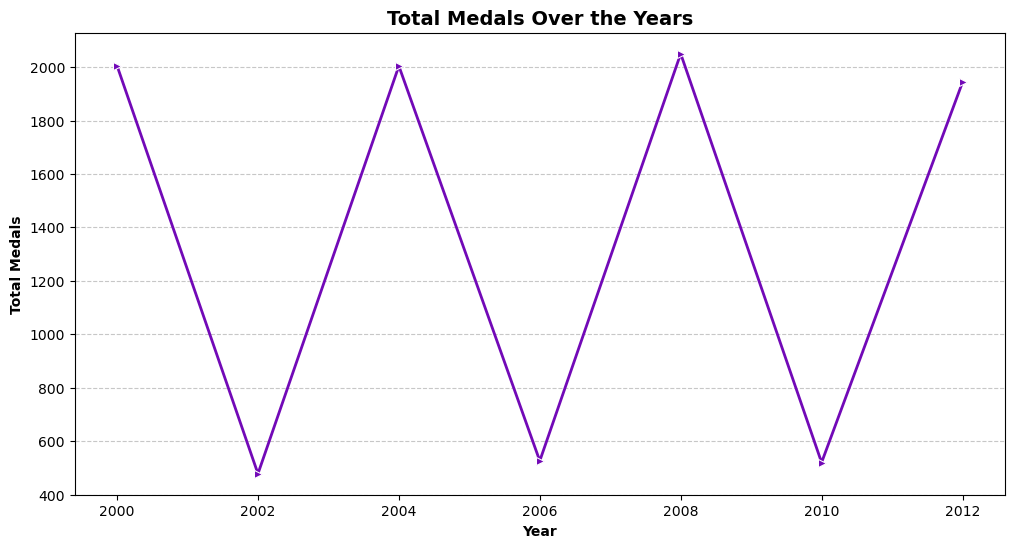

```python
dd = df.groupby("Year")["Total_Medals"].sum().reset_index()
plt.figure(figsize=(12, 6))
sns.lineplot(x="Year", y="Total_Medals", data=dd, marker=">", color="#7209B7", linewidth=2)
plt.title("Total Medals Over the Years", fontweight="bold", fontsize=14)
plt.xlabel("Year", fontweight="bold")
plt.ylabel("Total Medals", fontweight="bold")
plt.grid(axis="y", linestyle="--", alpha=0.7)
plt.show()
```

### 6.What is the average age of medal-winning athletes in different sports?

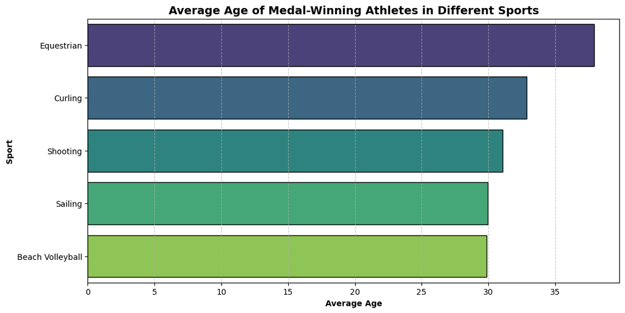

```python
dd= df.groupby("Sport")["Age"].mean().reset_index().sort_values(by="Age", ascending=False)
dd=dd.head(5)
plt.figure(figsize=(12, 6))
sns.barplot(x="Age", y="Sport", data=dd, palette="viridis", edgecolor="black")
plt.title("Average Age of Medal-Winning Athletes in Different Sports", fontweight="bold", fontsize=14)
plt.xlabel("Average Age", fontweight="bold")
plt.ylabel("Sport", fontweight="bold")
plt.grid(axis="x", linestyle="--", alpha=0.7)
plt.show()
```

### 7.What is the percentage distribution of total medals among different sports?

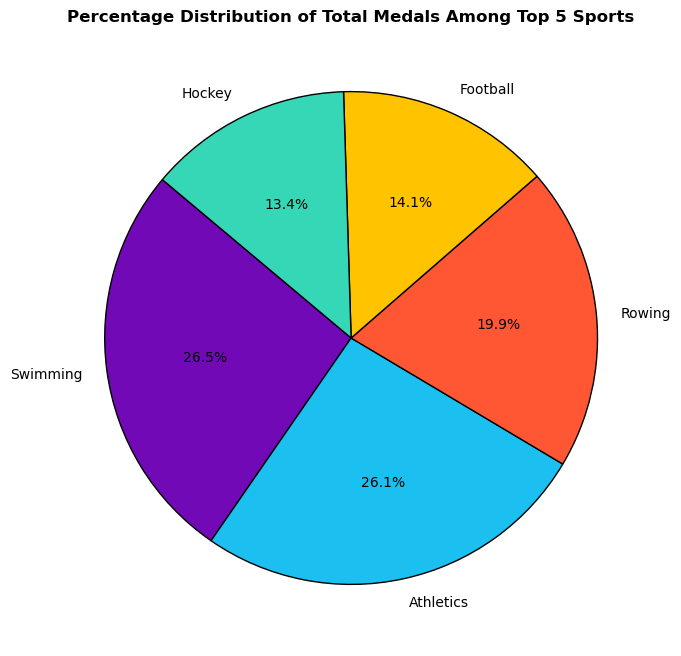

```python
dd= df.groupby("Sport")["Total_Medals"].sum().reset_index().sort_values(by="Total_Medals", ascending=False)
dd= dd.head(5)
plt.figure(figsize=(8, 8))
colors = ["#7209B7", "#1CC0F0", "#FF5733", "#FFC300", "#36D7B7"]
plt.pie(dd["Total_Medals"], labels=dd["Sport"], autopct="%1.1f%%", colors=colors, startangle=140, wedgeprops={"edgecolor": "black"})
plt.title("Percentage Distribution of Total Medals Among Top 5 Sports", fontweight="bold")
plt.show()
```

### Recommendation

To improve performance in the Olympics, countries should invest in swimming and athletics, as they contribute the highest medal counts. Training programs should focus on athletes aged 30-40, especially in equestrian and curling, where experience plays a key role. Identifying and nurturing young talent early can help nations compete at the highest level. Additionally, analyzing past trends can guide better resource allocation for future events.